# Module 8 HW McSpadden_Diana

Diana McSpadden

4/1/2021

# Q7

In the lab, we applied random forests to the Boston data using mtry=6 and using ntree=25 and ntree=500. Create a plot displaying the test error resulting from random forests on this data set for a more comprehensive range of values for mtry and ntree. You can model your plot after Figure 8.10. Describe the results obtained.

```r
library(MASS)
library(tree)
library(tidyverse)
library(partykit)
library(rattle)
```

```r
library(rpart.plot)
library(RColorBrewer)
library(randomForest)
```

Setup train and test observations

```r
boston <- MASS::Boston
set.seed(1976)

n = nrow(boston)


train = sample(1: nrow(boston ), 406, replace = FALSE) # 406 training observations
```

The argument **mtry=13** indicates that all 13 predictors should be considered for each split of the tree.

I want to run for m = range(1:13).

We change the number of trees grown by randomForest() using the **ntree** argument.

I want to run with ntree in seq(from = 25, to = 500, by = 25)

```r
out_trees = tibble()

for (m in c(1,4,7,10,13))
{
  for (nt in seq(from = 1, to = 1000, by = 25))
  {
    set.seed(200)
    tree_model = randomForest(medv∼., data = boston, subset=train, mtry = m, ntree = nt)
    preds = predict(tree_model, newdata = boston[-train,])
    preds_err = mean((preds - boston[-train, ]$medv)^2)

    # save the tuning and errors
    out_trees = bind_rows(out_trees, tibble(mtry = m, ntree = nt, err = preds_err))
  }
}
```

```r
# can save mtry as a factor and then the plot will color correctly
out_trees %>% mutate(mtry = factor(mtry)) %>% filter(err == min(err))
```

```
## # A tibble: 1 x 3
##   mtry  ntree   err
##   <fct> <dbl> <dbl>
## 1 7        51  6.57
```

Now I will create a plot:

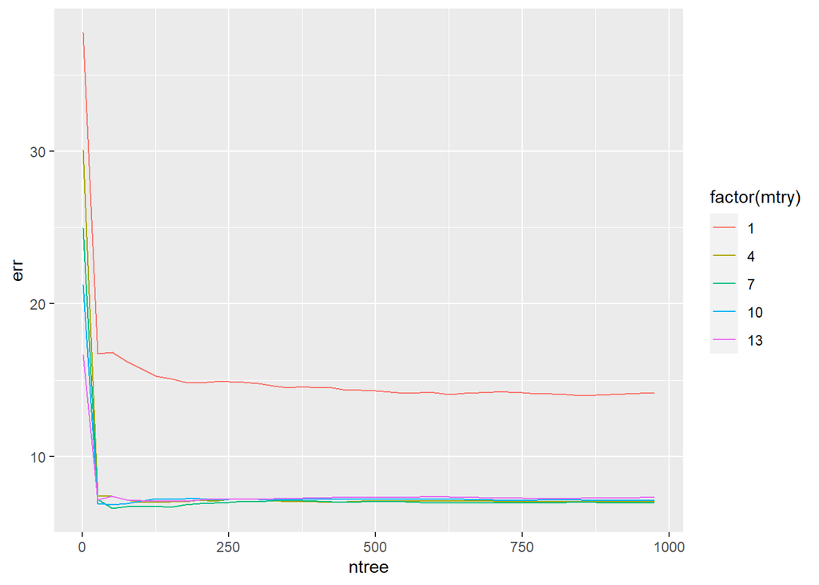

```r
out_trees %>% ggplot(aes(x = ntree, y = err, color=factor(mtry))) + geom_line() #+ geom_point(aes(colour = factor(mtry))) #
```

# Question 8

In the lab, a classification tree was applied to the Carseats data set after converting Sales into a qualitative response variable. Now we will seek to predict Sales using regression trees and related approaches, treating the response as a quantitative variable.

## (a) Split the data set into a training set and a test set.

carseats has 400 observations. There are 10 predictor variables. This gives 40 observations per predictor without splitting.

I belive this is a small number of observations per predictor, so I am going to set aside only 50 observations for testing.

```r
library(ISLR)
```

```r
carseats = Carseats
# make the right fields factors because it helps with plots and other functions down the road.
carseats = carseats %>% mutate(ShelveLoc = factor(ShelveLoc), Urban = factor(Urban), US = factor(US))
#head(carseats)
```

```r
# create training and test partitions
set.seed(1980)
train_inds = sample(1: nrow(carseats), 350, replace = FALSE) # 350 training observations
training_carseats = carseats[train_inds,]
testing_carseats = carseats[-train_inds,]
```

## (b) Fit a regression tree to the training set.

Plot the tree, and interpret the results. What test MSE do you obtain?

**Question Q8b Process:**  
Here I will use the tree library for the initial regression tree:

```r
library(tree)
q8b_tree = tree(Sales~.,training_carseats)

summary(q8b_tree)
```

```
##
## Regression tree:
## tree(formula = Sales ~ ., data = training_carseats)
## Variables actually used in tree construction:
## [1] "ShelveLoc"   "Price"       "CompPrice"   "Income"      "Advertising"
## [6] "Age"         "US"
## Number of terminal nodes:  16
## Residual mean deviance:  2.578 = 861 / 334
## Distribution of residuals:
##     Min.  1st Qu.   Median     Mean  3rd Qu.     Max.
## -4.84200 -1.01400 -0.01938  0.00000  1.02100  5.12400
```

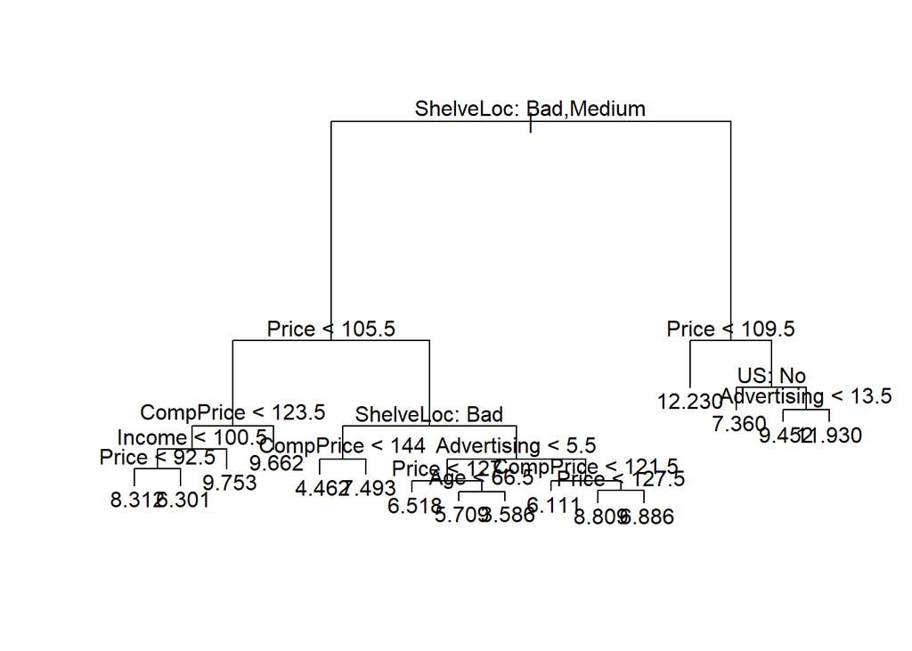

```r
plot(q8b_tree)
text(q8b_tree,pretty=0)
```

**Answer Q8b:** The tree created uses 7 predictors in the regression tree to predict Sales (in thousands), resulting in 16 terminal nodes. The 7 predictors are:

1. ShelveLoc
2. Price
3. CompPrice
4. Income
5. Advertising
6. Age
7. US

The Residual mean deviance is **2.578** for this tree.

**With rpart:**  
I will also try create the tree with teh rpart library, with input parameter cp=-1 which creates a fully-grown tree. I am also requesting no corss-validation (but I have had mixed results as to whether the xval=0 parameter works as described in documentation).

```r
q8b_tree_full = rpart::rpart(Sales~., data=training_carseats, method='anova', parms=list(split='information'), xval=0)
q8b_tree_full_cp = printcp(q8b_tree_full)
```

```
##
## Regression tree:
## rpart::rpart(formula = Sales ~ ., data = training_carseats, method = "anova",
##     parms = list(split = "information"), xval = 0)
##
## Variables actually used in tree construction:
## [1] Advertising Age         CompPrice   Income      Price       ShelveLoc
## [7] US
##
## Root node error: 2710.9/350 = 7.7455
##
## n= 350
##
##          CP nsplit rel error
## 1  0.268591      0   1.00000
## 2  0.105219      1   0.73141
## 3  0.057482      2   0.62619
## 4  0.040903      3   0.56871
## 5  0.027947      4   0.52781
## 6  0.027285      5   0.49986
## 7  0.025953      6   0.47257
## 8  0.024165      7   0.44662
## 9  0.020937      8   0.42246
## 10 0.015144      9   0.40152
## 11 0.014088     10   0.38637
## 12 0.013589     11   0.37229
## 13 0.013352     13   0.34511
## 14 0.011258     14   0.33176
## 15 0.010000     15   0.32050
```

```r
df.cp = data.frame(q8b_tree_full_cp)
df.cp
```

```
##            CP nsplit rel.error
## 1  0.26859055      0 1.0000000
## 2  0.10521864      1 0.7314095
## 3  0.05748247      2 0.6261908
## 4  0.04090252      3 0.5687083
## 5  0.02794746      4 0.5278058
## 6  0.02728456      5 0.4998584
## 7  0.02595334      6 0.4725738
## 8  0.02416524      7 0.4466205
## 9  0.02093675      8 0.4224552
## 10 0.01514367      9 0.4015185
## 11 0.01408814     10 0.3863748
## 12 0.01358871     11 0.3722867
## 13 0.01335211     13 0.3451092
## 14 0.01125805     14 0.3317571
## 15 0.01000000     15 0.3204991
```

As you can see, the resulting tree is overly complex:

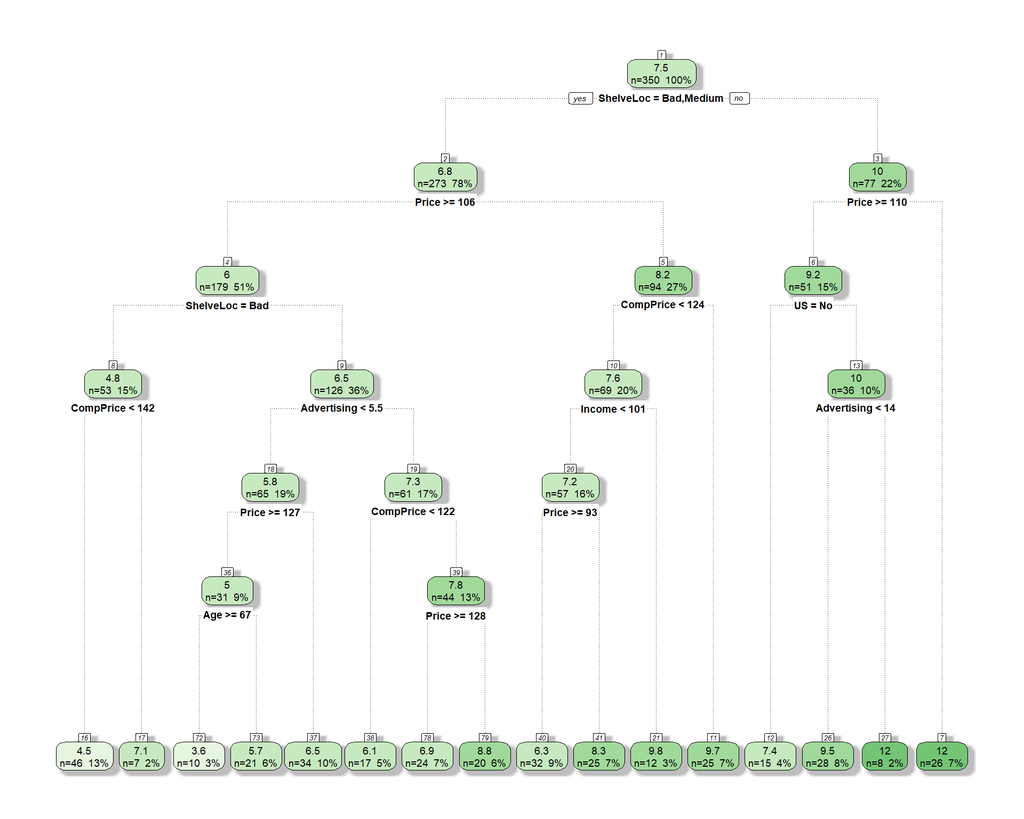

```r
#summary(q8b_tree_full)
fancyRpartPlot(q8b_tree_full, caption = NULL)
```

## (c) Use cross-validation …

in order to determine the optimal level of tree complexity. Does pruning the tree improve the test MSE?

**First cross validation with base R**

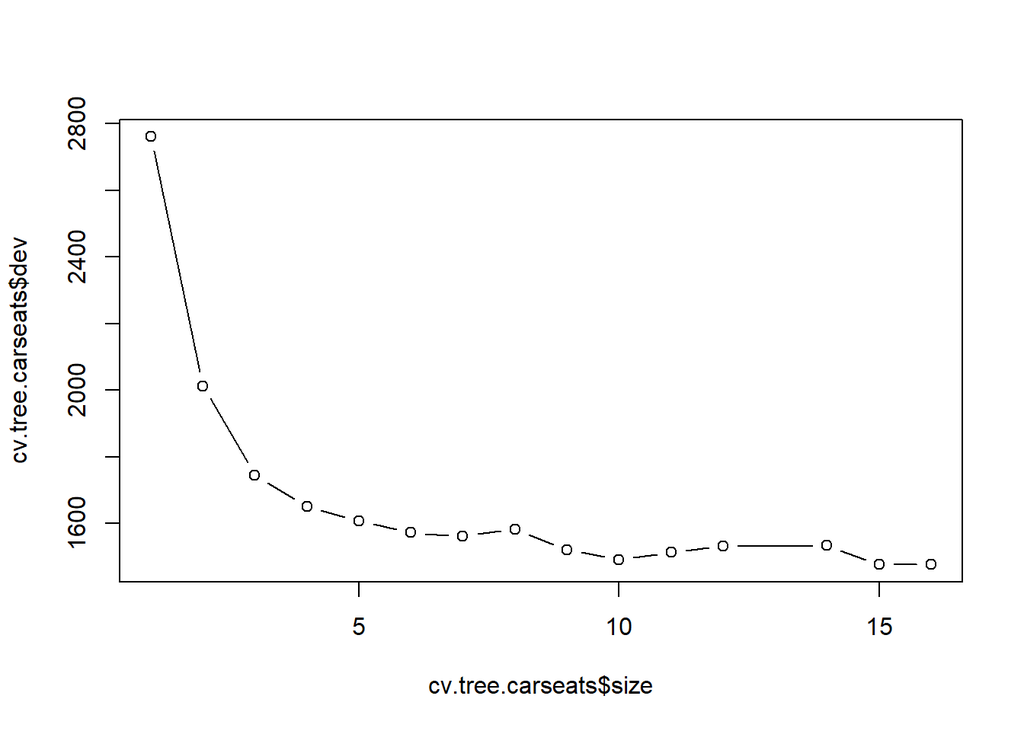

```r
cv.tree.carseats = cv.tree(q8b_tree)
plot(cv.tree.carseats$size, cv.tree.carseats$dev, type='b')
```

**Answer q8c:** Cross-validation results in 15 terminal nodes instead of 16 terminal nodes.

```r
q8c_tree = rpart::rpart(Sales~., data=training_carseats, method='anova', xval=10)
q8c_tree_cp = printcp(q8c_tree)
```

```
##
## Regression tree:
## rpart::rpart(formula = Sales ~ ., data = training_carseats, method = "anova",
##     xval = 10)
##
## Variables actually used in tree construction:
## [1] Advertising Age         CompPrice   Income      Price       ShelveLoc
## [7] US
##
## Root node error: 2710.9/350 = 7.7455
##
## n= 350
##
##          CP nsplit rel error  xerror     xstd
## 1  0.268591      0   1.00000 1.00544 0.075548
## 2  0.105219      1   0.73141 0.73871 0.052872
## 3  0.057482      2   0.62619 0.65592 0.046855
## 4  0.040903      3   0.56871 0.61150 0.043766
## 5  0.027947      4   0.52781 0.59152 0.043638
## 6  0.027285      5   0.49986 0.59943 0.046650
## 7  0.025953      6   0.47257 0.60435 0.046839
## 8  0.024165      7   0.44662 0.58940 0.045267
## 9  0.020937      8   0.42246 0.57238 0.044524
## 10 0.015144      9   0.40152 0.56483 0.043894
## 11 0.014088     10   0.38637 0.56712 0.043896
## 12 0.013589     11   0.37229 0.57037 0.043621
## 13 0.013352     13   0.34511 0.56748 0.043532
## 14 0.011258     14   0.33176 0.55048 0.041911
## 15 0.010000     15   0.32050 0.54926 0.040990
```

```r
df.cp.xval = data.frame(q8c_tree_cp)
df.cp.xval
```

```
##            CP nsplit rel.error    xerror       xstd
## 1  0.26859055      0 1.0000000 1.0054442 0.07554819
## 2  0.10521864      1 0.7314095 0.7387071 0.05287211
## 3  0.05748247      2 0.6261908 0.6559195 0.04685460
## 4  0.04090252      3 0.5687083 0.6115035 0.04376590
## 5  0.02794746      4 0.5278058 0.5915210 0.04363785
## 6  0.02728456      5 0.4998584 0.5994306 0.04665033
## 7  0.02595334      6 0.4725738 0.6043525 0.04683897
## 8  0.02416524      7 0.4466205 0.5894041 0.04526657
## 9  0.02093675      8 0.4224552 0.5723776 0.04452412
## 10 0.01514367      9 0.4015185 0.5648292 0.04389418
## 11 0.01408814     10 0.3863748 0.5671174 0.04389643
## 12 0.01358871     11 0.3722867 0.5703732 0.04362119
## 13 0.01335211     13 0.3451092 0.5674821 0.04353228
## 14 0.01125805     14 0.3317571 0.5504822 0.04191104
## 15 0.01000000     15 0.3204991 0.5492620 0.04098963
```

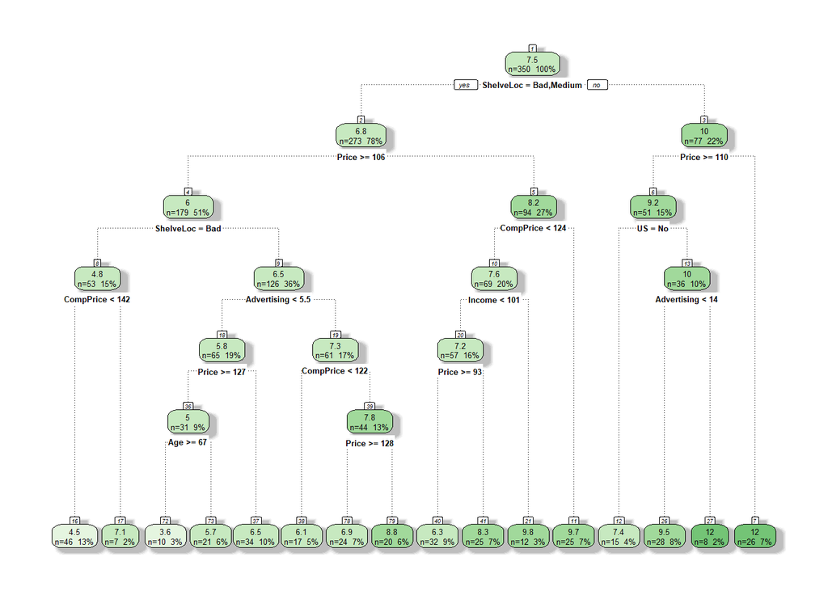

```r
fancyRpartPlot(q8c_tree, caption = NULL)
```

**Answer q8c:** The residual mean deviance is 7.75 * 0.32 = **2.48** which is less than 2.578 from the not cross-validated tree.

## (d) Use the bagging approach …

in order to analyze this data. What test MSE do you obtain? Use the importance() function to determine which variables are most important.

**Q8d Process:** Bagging creates an essemble model with bagged observations, and testing a tree on it’s out-of-bag observations. I will use the caret package for bagging.

Bagging can be done where randomforest is set to the total number of predictors. In the carseats case, this is **10**.

```r
set.seed(1976)

bagging.carseats = caret::train(Sales~., data=carseats, method='rf', #because we are using caret, we aren't splitting into training and test
                              importance=FALSE, ntree=500,
                              tuneGrid=data.frame(mtry=10), #set mtry to 10
                 trControl=caret::trainControl("cv", number=5, savePredictions=TRUE, returnResamp='all'))
# print the final model
bagging.carseats$finalModel
```

```
##
## Call:
##  randomForest(x = x, y = y, ntree = 500, mtry = param$mtry, importance = FALSE)
##                Type of random forest: regression
##                      Number of trees: 500
## No. of variables tried at each split: 10
##
##           Mean of squared residuals: 2.285281
##                     % Var explained: 71.27
```

**Using the importance function*:*

```r
as.data.frame(randomForest::importance(bagging.carseats$finalModel)) %>% arrange(IncNodePurity)
```

```
##                 IncNodePurity
## UrbanYes             13.41759
## USYes                15.08450
## Education            82.61545
## Population          100.78090
## ShelveLocMedium     174.41163
## Income              175.10013
## Advertising         233.95062
## Age                 284.48902
## CompPrice           329.63066
## ShelveLocGood       793.32635
## Price               901.08309
```

**Answer Q8:** Bagging descreased the MSE even more to **2.28**.

The predictors listed from most to least importance are:

1. Price
2. ShelveLoc Is Good
3. CompPrice
4. Age
5. Advertising
6. Income
7. ShelveLoc Is Medium
8. Population
9. Education
10. US Is Yes
11. Urban Is Yes

## (e) Use random forests to analyze this data.

What test MSE do you obtain? Use the importance() function to determine which variables are most important. Describe the effect of m, the number of variables considered at each split, on the error rate obtained.

```r
out_trees_q8 = tibble()

for (m in c(1, 4, 7, 9, 10))
{
  for (nt in seq(from = 1, to = 1000, by = 50))
  {
    set.seed(1976)
    tree_model_q8 = randomForest(Sales∼., data = training_carseats, mtry = m, ntree = nt)
    preds_q8 = predict(tree_model_q8, newdata = testing_carseats)
    preds_err_q8 = mean((preds_q8 - testing_carseats$Sales)^2)

    # save the tuning and errors
    out_trees_q8 = bind_rows(out_trees_q8, tibble(mtry = m, ntree = nt, err = preds_err_q8))
  }
}

out_trees_q8 %>% mutate(mtry = factor(mtry)) %>% filter(err == min(err))
```

```
## # A tibble: 1 x 3
##   mtry  ntree   err
##   <fct> <dbl> <dbl>
## 1 9        51  2.94
```

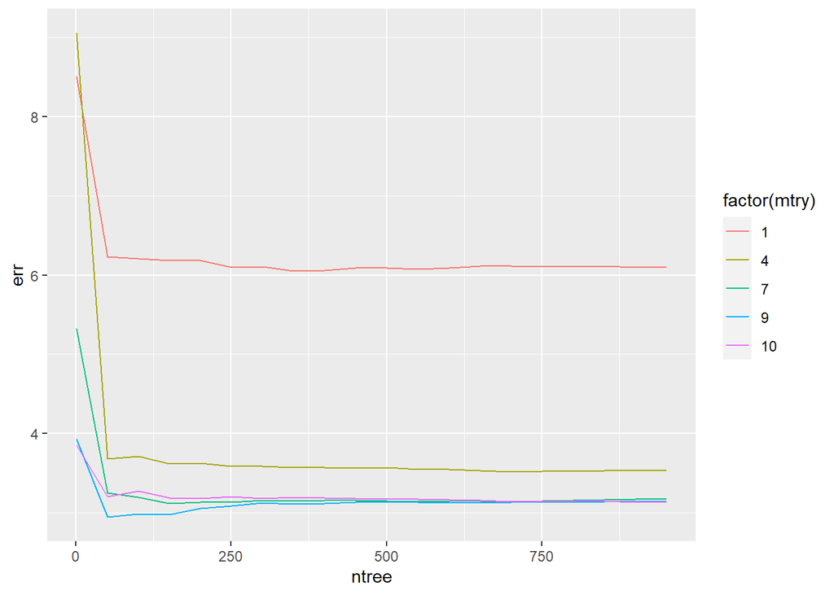

```r
out_trees_q8 %>% ggplot(aes(x = ntree, y = err, color=factor(mtry))) + geom_line()
```

**Viewing Importance**

First, create the specific tree with the correct mtry and cp.

```r
tree.carseats.e = randomForest(Sales∼., data = training_carseats, mtry = 9, ntree = 51)

as.data.frame(randomForest::importance(tree.carseats.e)) %>% arrange(IncNodePurity)
```

```
##             IncNodePurity
## Urban            14.61321
## US               19.74025
## Education        72.73005
## Population       80.34629
## Income          133.45834
## Advertising     203.50559
## Age             230.66053
## CompPrice       279.21906
## Price           758.68584
## ShelveLoc       854.76726
```

# Question 11

This question uses the Caravan data set.

## (a) Create a training set consisting of the first 1,000 observations,

and a test set consisting of the remaining observations.

**Q11 a Process:** I did as requested, but it seems odd to only train on the first 1000 observations when we have 5822 observations to use. I would have expected the training set to be the larger portion of the observations.

```r
caravan = ISLR::Caravan

caravan = caravan %>% mutate(Purchase = ifelse(Purchase == "Yes",1,0)) #%>% mutate(Purchase = factor(Purchase))
#head(caravan)

caravan_training = caravan[1:1000,]
caravan_testing= caravan[1001:nrow(caravan),]

#head(caravan_training)
```

## (b) Fit a boosting model to the training set…

with Purchase as the response and the other variables as predictors. Use 1,000 trees, and a shrinkage value of 0.01. Which predictors appear to be the most important?

**Q11 b Process:** I am going to attempt to follow the eXtreme Gradient Boosting example video. It uses xgboost library.

I don’t know enough about the caravan dataset, and the R documentation isn’t clear, about which predictors are factors with levels, which are one hot encoded, etc. I am going to leave the datast as is with numeric data types, except for Purchase which is a factor.

```r
library(xgboost)
library(magrittr)
library(dplyr)
library(Matrix)

#str(caravan_training)
```

## (c) Use the boosting model to predict the response on the test data.

Predict that a person will make a purchase if the estimated probability of purchase is greater than 20%. Form a confusion matrix. What fraction of the people predicted to make a purchase do in fact make one? How does this compare with the results obtained from applying KNN or logistic regression to this data set?

**Fit KNN - need to find a good K for KNN:** Fit on training data, and test on the hold out data.

```r
library(class)

# prep the data for KNN
# standardize the Caravan dataset
standardized.X = scale(ISLR::Caravan[,-86]) # remove Purchase from the scaling.

#create the KNN train and test data sets
test = 1001:nrow(ISLR::Caravan) #first 1000 observations
KNN.train.X = standardized.X[-test ,]
KNN.test.X = standardized.X[test ,]
KNN.train.Y = ISLR::Caravan$Purchase[-test]
KNN.test.Y = ISLR::Caravan$Purchase[test]

out_knn_q11 = tibble()

# I tried a few values of knn, and 5 was the best balance of bias and variance (and matches the textbook's findings)
for (knn in c(5))
{
  set.seed (1976)
  knn_preds = knn(KNN.train.X, KNN.test.X, KNN.train.Y, k=knn)
  knn_err = mean(KNN.test.Y != knn_preds)

  # save the mean mis-classified
  out_knn_q11 = bind_rows(out_knn_q11, tibble(knn = knn, err = knn_err))

}

out_knn_q11 = out_knn_q11 %>% mutate(knn = factor(knn))

out_knn_q11 %>% filter(err == min(err))
```

```
## # A tibble: 1 x 2
##   knn      err
##   <fct>  <dbl>
## 1 5     0.0633
```

```r
table(knn_preds, KNN.test.Y)
```

```
##          KNN.test.Y
## knn_preds   No  Yes
##       No  4507  279
##       Yes   26   10
```

The TPR For KNN | k == 5 is 10 / 36 == **0.278**

**Fit logistic Regression:** Fit on training data, and test on the hold out data. Per the textbook a p of 0.25 is the threshold to use:

```r
# make the glm model
q11.glm.model = glm(Purchase~., data=ISLR::Caravan, family="binomial", subset = -test)

# make the predictions
q11.glm.preds = predict(q11.glm.model, ISLR::Caravan[test,], type="response")

# per the textbook a probability of 0.25 makes better predictions
q11.gl.predictions = rep("No", 1000)
q11.gl.predictions[q11.glm.preds > 0.25] = "Yes"
# print the confusion matrix
table(q11.gl.predictions, KNN.test.Y)
```

```
##                   KNN.test.Y
## q11.gl.predictions  No Yes
##                No  903  55
##                Yes 253  45
```

The glm model with p = 0.25 has a True Positive Rate of 45 / 298 == **0.15**

**Now to try the xgboost method:** with 1,000 iterations/trees , and a shrinkage value of 0.01.

```r
# create one-hot encoding for factor variables
#caravan_testing = caravan[1:1000,]
#caravan_training = caravan[1001:nrow(caravan),]

trainm = sparse.model.matrix(Purchase~.-Purchase, data = caravan_training) # remove the 86th variable which is Purchase
#head(trainm)
train_label = caravan_training[,"Purchase"]
train_matrix = xgb.DMatrix(data = as.matrix(trainm), label = train_label)


testm = sparse.model.matrix(Purchase~.-Purchase, data = caravan_testing) # remove the 86th variable which is Purchase
#head(trainm)
test_label = caravan_testing[,"Purchase"]
test_matrix = xgb.DMatrix(data = as.matrix(testm), label = test_label)

# Parameters
# number of classes
nc = length(unique(train_label))

#eta = the learning rate, set to 0.01, which is low ==  more robust to overfitting, slower to compute
xgb_params = list("objective" = "multi:softprob", "eval_metric" = "mlogloss", "num_class" = nc, eta = 0.01)

# create a watchlist, so we evaluate the model (how much error at each iteration)
watchlist = list(train = train_matrix, test = test_matrix)

# try with eXtreme Gradient Boosting Model
boost_model = xgb.train(params = xgb_params, data = train_matrix, nrounds = 1000, watchlist = watchlist, print_every_n = 25)
```

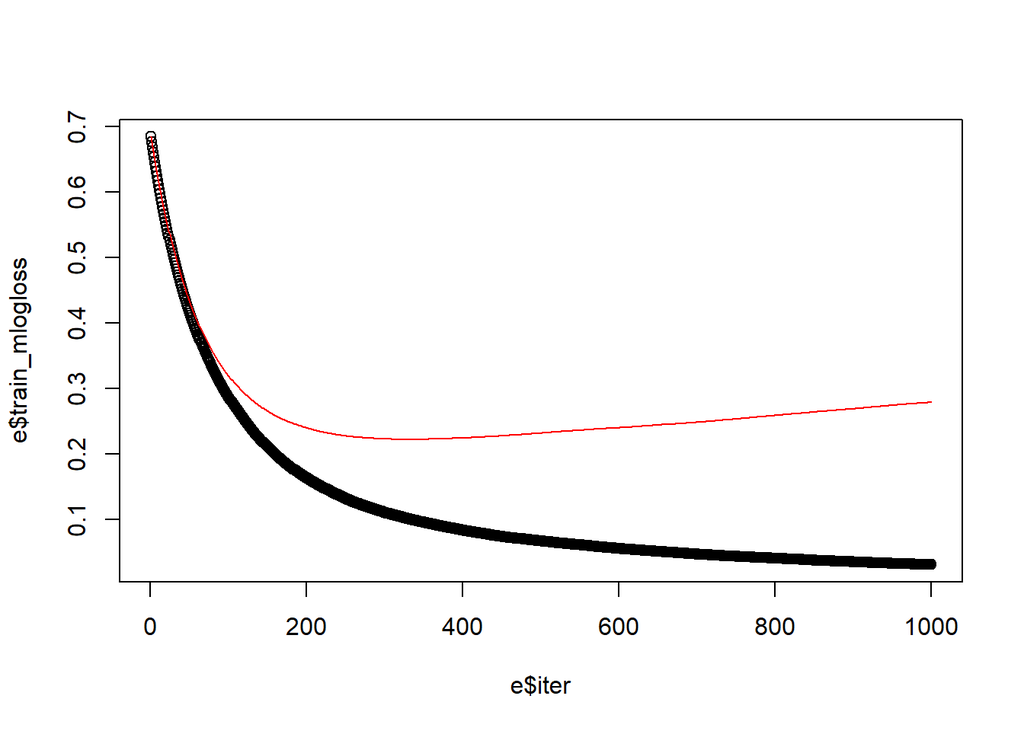

```r
e = data.frame(boost_model$evaluation_log)
plot(e$iter, e$train_mlogloss)
lines(e$iter, e$test_mlogloss, col='red')
```

```r
min(e$test_mlogloss)
```

```
## [1] 0.222185
```

```r
e[e$test_mlogloss == 0.222185,]
```

```
##     iter train_mlogloss test_mlogloss
## 334  334       0.100084      0.222185
```

Now to check feature importance:

```r
importance = xgb.importance(colnames(train_matrix), model = boost_model)
importance
```

```
##      Feature         Gain        Cover    Frequency
##  1: PPERSAUT 6.480873e-02 1.322031e-01 3.295622e-02
##  2:  MOSTYPE 5.761397e-02 3.567855e-02 6.607641e-02
##  3: MBERMIDD 5.700406e-02 6.490480e-02 4.361371e-02
##  4:   MGODGE 5.419591e-02 3.408244e-02 4.252063e-02
##  5: MINK3045 3.677532e-02 4.128350e-02 3.721922e-02
##  6: MOPLHOOG 3.613958e-02 2.252714e-02 2.549598e-02
##  7:   MGODPR 3.143066e-02 7.012247e-03 2.831065e-02
##  8: MBERARBG 3.097460e-02 1.927970e-02 3.683664e-02
##  9:  MINKM30 2.937139e-02 3.673745e-02 3.123463e-02
## 10:  MZFONDS 2.929589e-02 9.580403e-03 2.202547e-02
## 11: PPLEZIER 2.899304e-02 6.834850e-02 2.475816e-02
## 12: MBERARBO 2.873227e-02 1.536113e-02 2.904848e-02
## 13:   MHHUUR 2.768514e-02 1.617383e-02 2.989561e-02
## 14: MKOOPKLA 2.723334e-02 3.077192e-02 3.120730e-02
```

[output cut: 45 more lines]

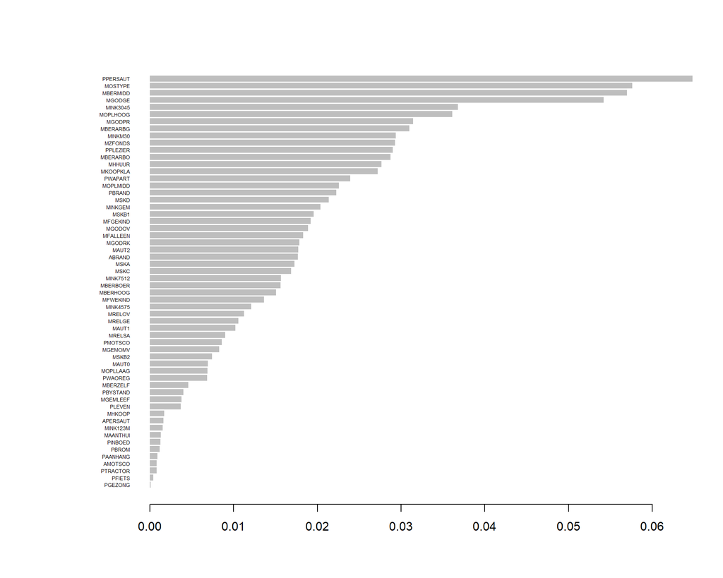

```r
xgb.plot.importance(importance)
```

By **Gain** PPERSAUT is the most important, followed by MOSTYPE, MBERMIDO, MGOGDE, and MINK3045.

**Create Predictions And A Confusion Matrix**

Below, p is the probability that the customer Purchased the insurance or didn’t purchase the insurance. First Value == Didn’t, Second Value == Did, etc etc.

```r
p = predict(boost_model, newdata = test_matrix)
#head(p)

prod = matrix(p, nrow = nc, ncol = length(p)/nc) %>%
  t() %>%
  data.frame() %>%
  mutate(label = test_label, max_prob = max.col(., "last")-1)

head(prod)
```

```
##          X1          X2 label max_prob
## 1 0.9976877 0.002312260     0        0
## 2 0.9915046 0.008495428     1        0
## 3 0.9857201 0.014279975     0        0
## 4 0.9786260 0.021373972     0        0
## 5 0.3289275 0.671072423     0        1
## 6 0.9405437 0.059456237     1        0
```

And, the confusion matrix

```r
table(Prediction = prod$max_prob, Actual = prod$label)
```

```
##           Actual
## Prediction    0    1
##          0 4465  277
##          1   68   12
```

True Positive Rate for Test Data Using Boosting With a threshold of 0.5 is 12 / 80 == **0.15** (the same as the glm model with threshold of 0.25).

But what happens when we use the threshold requested by the textbook, p == 0.2, on the boosted model.

```r
prod = prod %>% mutate(prob25 = ifelse(X2 >= 0.2,1,0))

#caravan = caravan %>% mutate(Purchase = ifelse(Purchase == "Yes",1,0)) #%>% mutate(Purchase = factor(Purchase))

table(Prediction = prod$prob25, Actual = prod$label)
```

```
##           Actual
## Prediction    0    1
##          0 4364  265
##          1  169   24
```

However, I tested several threshold values and the best was:

```r
for (thres in c(.1,.2,.3,.4,.6,.8,.9))
{
  prod = prod %>% mutate(prob25 = ifelse(X2 >= thres,1,0))
  df.prod = as.data.frame(table(Prediction = prod$prob25, Actual = prod$label))
  truepositive = df.prod[4,3]
  falsepositive = df.prod[2,3]
  tpr = truepositive / (truepositive + falsepositive)
  print(paste('For threshold = ', thres, ' TPR = ', tpr, '(TP: ', truepositive, 'FP: ', falsepositive,')'))
}
```

```
## [1] "For threshold =  0.1  TPR =  0.11849710982659 (TP:  41 FP:  305 )"
## [1] "For threshold =  0.2  TPR =  0.124352331606218 (TP:  24 FP:  169 )"
## [1] "For threshold =  0.3  TPR =  0.14 (TP:  21 FP:  129 )"
## [1] "For threshold =  0.4  TPR =  0.150442477876106 (TP:  17 FP:  96 )"
## [1] "For threshold =  0.6  TPR =  0.169230769230769 (TP:  11 FP:  54 )"
## [1] "For threshold =  0.8  TPR =  0.260869565217391 (TP:  6 FP:  17 )"
## [1] "For threshold =  0.9  TPR =  0.333333333333333 (TP:  2 FP:  4 )"
```

A threshold of 0.9 provides a better TPR, BUT only identifies 2 true positives, and 4 false positives which is not all that useful. The threshold where the most purchasers were identified is a p of 0.1, with a TPR of 0.12.